# Coursera Capstone Project Report

Bright

`3/21/2025`

# Cyclistic Bike Share Usage Analysis

## Business Task Statement

To analyze how annual members and casual riders use Cyclistic bikes differently to identify key usage patterns and provide actionable recommendations to support strategic decision-making.

## Data Sources

The data used for this analysis was provided by Motivate International Inc. under the data license agreement available at: https://www.divvybikes.com/data-license-agreement. This is publicly available data intended to explore customer behaviors and usage trends for Cyclistic bikes.

## Data Cleaning and Preparation Process

To ensure the dataset was ready for accurate and meaningful analysis, the following steps were taken:

#### Data Import and Consolidation

- Monthly datasets (12 Excel workbooks) were consolidated into a single dataset.
- All files were verified for consistent column headers and data structure.

#### Standardization and Cleaning

- Column headers were standardized.
- Data types were verified and corrected where necessary (e.g., date fields and numeric values).

#### New Calculated Columns

- Average Ride Length: Created to summarize the duration of each ride.
- Day of the Week: Extracted from ride start times using Excel’s TEXT function for weekday analysis.

#### Pivot Charts and Data Exploration

- Monthly Trends: Analyzed average ride lengths by month and rider type.
- Weekday Patterns: Visualized ride frequency and duration by day of the week.

#### Descriptive Statistics

- Computed minimum, maximum, and mode of ride lengths.
- Identified the mode day (most frequent ride day) for both rider types.

#### Data Consistency Checks

- Verified uniqueness of ride IDs and consistency of key fields like rideable type and timestamps.

#### Final Dataset Preparation

- Cleaned data with added insights was used for advanced analysis, forecasting, and pattern recognition.

## Supporting Visualizations and Key Findings

The pivoted datasets were now imported into RStudio for further analysis and visualisation using R programming.

## Setting up my environment

Note: I set up my environment by installing and loading the ‘tidyverse’ and ‘ggplot2’ packages:

```r
library(tidyverse)
```

```r
library(ggplot2)
```

```r
average_rides <- readRDS("average_rides.rds")
```

```r
view(average_rides)
```

## Average Ride Length by User Type

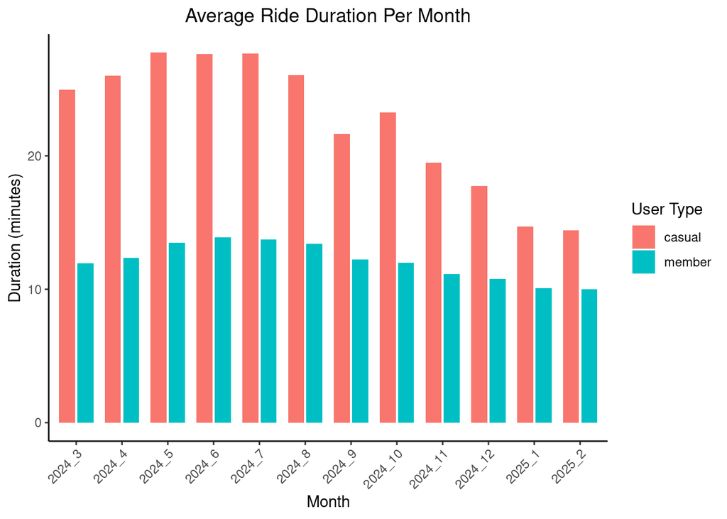

```r
ggplot(average_rides, aes(x = month, y = duration_minutes, fill = user_type)) +
  geom_bar(stat = "identity", position = position_dodge(width = 0.8), width = 0.7) +
  labs(title = "Average Ride Duration Per Month",
           x = "Month",
           y = "Duration (minutes)",
           fill = "User Type") +
  theme_classic() +
  theme(plot.title = element_text(hjust = 0.5),
    axis.text.x = element_text(angle = 45, hjust = 1))
```

Based on the visualization;

- Casual riders have a higher average ride length compared to members.
- Casual usage spikes seasonally, peaking during warmer months.

## Preferred Rideable Type

```r
preferred_rides <- read.csv("Preferred Rideable Type.csv")
```

```r
preferred_rides <- rename(preferred_rides, 'total_rides' = Sum.of.total_rides)
```

```r
view(preferred_rides)
```

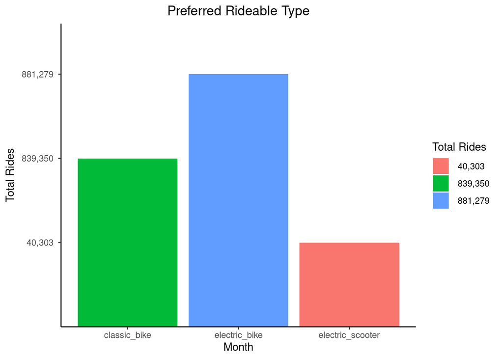

```r
ggplot(preferred_rides, aes(x = ride_month, y = total_rides, fill = total_rides)) +
  geom_bar(stat = "identity") +
  labs(title = "Preferred Rideable Type",
           x = "Month",
           y = "Total Rides",
           fill = "Total Rides") +
  theme_classic() +
  theme(plot.title = element_text(hjust = 0.5),  # Center the title
    axis.text.x = element_text(angle = 0, hjust = 0.5)) # Center x-axis labels under bars
```

## Number of Rides Per Day of the Week

```r
rides_per_day <- read.csv("Number of Rides Per Day of the Week.csv")
```

```r
view(rides_per_day)
```

```r
library(scales)
```

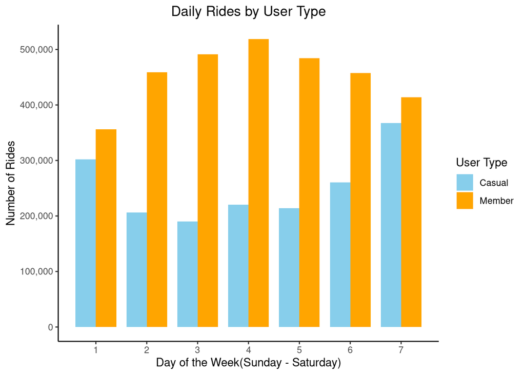

```r
ggplot() +
  geom_bar(aes(x = rides_per_day$week - 0.2, y = rides_per_day$casual, fill = "Casual"),
           stat = "identity", width = 0.4) +
  geom_bar(aes(x = rides_per_day$week + 0.2, y = rides_per_day$member, fill = "Member"),
           stat = "identity", width = 0.4) +
  scale_fill_manual(values = c("Casual" = "skyblue", "Member" = "orange")) +
  scale_x_continuous(breaks = rides_per_day$week) +
  scale_y_continuous(labels = comma) +
  labs(title = "Daily Rides by User Type", x = "Day of the Week(Sunday - Saturday)", y = "Number of Rides", fill = "User Type") +
  theme_classic() +
  theme(plot.title = element_text(hjust = 0.5))
```

Based on the visualization;

- Weekends see more casual ridership, while members show consistent weekday usage.

## Top Three Recommendations

#### Seasonal Promotions for Membership Conversion

- Offer targeted promotions (e.g., summer discounts, free trial months) to convert casual riders during peak seasons.

#### Customized Membership Options

- Introduce flexible memberships (e.g., weekend-only, premium routes) tailored to casual rider preferences.

#### Incentives and Loyalty Programs

- Implement a points-based loyalty system for casual riders to earn rewards and discounts toward membership.
- Provide winter incentives like gear discounts to maintain engagement during low-use seasons.

This was a great learning journey for me. All thanks to Coursera You can also learn new things.